# Leis de cinto salvam vidas?

Dados em painel e efeitos fixos — painel *SeatBelts*, 51 estados americanos, 1983–1997

Autor

Vítor Wilher

Data de Publicação

setembro de 2026

Laboratório da **Aula 9** de Econometria (MPEF/FGV-EPGE, Prof. Marcelo Mello). Par do laboratório sobre o painel *Guns* — mesma técnica, caso diferente. Acompanha o capítulo 10 da apostila da disciplina. ← Voltar às Notas de Econometria

## 1 Objetivo

Este notebook é o par do laboratório sobre o painel *Guns*: mesma técnica — efeitos fixos —, aplicada a uma pergunta diferente, com uma estrutura de identificação **mais favorável** e um desfecho mais interessante.

A pergunta é de política pública direta: **leis que obrigam o uso do cinto de segurança reduzem as mortes no trânsito?**

Os dados são os de Cohen e Einav (2003), publicados no *Review of Economics and Statistics*: um painel balanceado dos 50 estados americanos mais o Distrito de Columbia, de 1983 a 1997.

O que torna o caso rico é que a lei vem em **duas intensidades**:

- **Fiscalização secundária** (*secondary enforcement*): a polícia só pode multar pelo cinto se já tiver parado o motorista por outra infração;
- **Fiscalização primária** (*primary enforcement*): o não uso do cinto é, por si só, motivo para parar o veículo.

Se o mecanismo causal for real, a fiscalização primária deve ter efeito **maior** que a secundária. Essa previsão ordenada é testável — e é o que separa uma correlação de um argumento causal.

```r
library(plm)
library(sandwich)
library(lmtest)
library(stargazer)
library(ggplot2)
suppressMessages(library(dplyr))
suppressMessages(library(tidyr))

theme_set(theme_minimal(base_size = 11) +
  theme(panel.grid.minor = element_blank(),
        legend.position = "bottom",
        legend.title = element_blank()))

az <- "#1f4e79"; vm <- "#b3261e"; vd <- "#2e7d32"; lr <- "#e07b00"; cz <- "grey45"
```

## 2 Importação e estrutura

```r
url <- paste0("https://raw.githubusercontent.com/vincentarelbundock/",
              "Rdatasets/master/csv/AER/USSeatBelts.csv")
bruto <- read.csv(url)

# harmoniza os nomes com os do arquivo da disciplina (SeatBelts.xls).
# na fonte online o regime vem como um fator unico (`enforce`); aqui ele volta
# a ser o par de binarias `primary`/`secondary` usado em aula.
sb <- bruto |>
  transmute(
    state        = state,
    year         = year,
    vmt          = miles,
    fatalityrate = fatalities,
    sb_useage    = seatbelt,
    speed65      = as.integer(speed65  == "yes"),
    speed70      = as.integer(speed70  == "yes"),
    drinkage21   = as.integer(drinkage == "yes"),
    ba08         = as.integer(alcohol  == "yes"),
    income       = income,
    age          = age,
    primary      = as.integer(enforce == "primary"),
    secondary    = as.integer(enforce == "secondary")
  )

dim(sb)
```

```
[1] 765  13
```

```r
names(sb)
```

```
 [1] "state"        "year"         "vmt"          "fatalityrate" "sb_useage"
 [6] "speed65"      "speed70"      "drinkage21"   "ba08"         "income"
[11] "age"          "primary"      "secondary"
```

O dicionário, conforme a documentação que acompanha os dados:

| Variável | Descrição |
| --- | --- |
| `fatalityrate` | **Mortes por milhão de milhas** trafegadas |
| `sb_useage` | Taxa de uso do cinto (fração, 0 a 1) |
| `primary` | 1 se havia lei com **fiscalização primária** |
| `secondary` | 1 se havia lei com **fiscalização secundária** |
| `speed65`, `speed70` | Limite de velocidade de 65 / 70+ mph |
| `ba08` | Limite de alcoolemia $\leq 0{,}08\%$ |
| `drinkage21` | Idade mínima de 21 anos para beber |
| `income` | Renda *per capita* |
| `age` | Idade média da população |
| `vmt` | Milhões de milhas trafegadas no ano |

Tabela 1: Dicionário do painel *SeatBelts*.

```r
c(estados     = length(unique(sb$state)),
  periodos    = length(unique(sb$year)),
  observacoes = nrow(sb),
  balanceado  = all(table(sb$state) == length(unique(sb$year))))
```

```
    estados    periodos observacoes  balanceado
         51          15         765           1
```

Painel **balanceado**: $51 \times 15 = 765$ observações, de 1983 a 1997.

### 2.1 Um aviso sobre dados faltantes

```r
colSums(is.na(sb))
```

```
       state         year          vmt fatalityrate    sb_useage      speed65
           0            0            0            0          209            0
     speed70   drinkage21         ba08       income          age      primary
           0            0            0            0            0            0
   secondary
           0
```

A variável `sb_useage` tem **209 valores faltantes** — os demais regressores estão completos. Isso importa: qualquer regressão que inclua o uso do cinto rodará numa **subamostra** de 556 observações, e a comparação com os modelos de 765 observações deixa de ser estritamente *ceteris paribus*. Voltaremos a isso na Seção 7, onde a variável é usada de propósito.

```r
sb <- sb |>
  mutate(
    lfat     = log(fatalityrate),
    l_income = log(income),
    # regime de fiscalizacao, como fator ordenado
    regime = case_when(
      primary   == 1 ~ "Primária",
      secondary == 1 ~ "Secundária",
      TRUE           ~ "Nenhuma"
    ) |> factor(levels = c("Nenhuma", "Secundária", "Primária"))
  )

psb <- pdata.frame(sb, index = c("state", "year"))
pdim(psb)
```

```
Balanced Panel: n = 51, T = 15, N = 765
```

## 3 Análise exploratória

### 3.1 A adoção das leis: de zero a quase todos

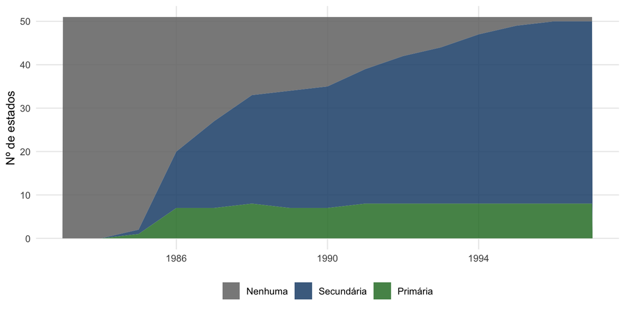

```r
adocao <- sb |>
  count(year, regime) |>
  complete(year, regime, fill = list(n = 0))

ggplot(adocao, aes(year, n, fill = regime)) +
  geom_area(alpha = 0.85) +
  scale_fill_manual(values = c("Nenhuma" = cz, "Secundária" = az, "Primária" = vd)) +
  labs(x = NULL, y = "Nº de estados")
```

A figura mostra a fonte da identificação. Em **1983 nenhum estado** tinha lei de cinto; em **1997, 50 dos 51** tinham. A transição é gradual e escalonada, concentrada entre 1985 e 1987.

```r
sb |>
  group_by(state) |>
  summarise(regimes = n_distinct(regime), .groups = "drop") |>
  count(regimes, name = "estados")
```

| regimes | estados |
| --- | --- |
| 1 | 1 |
| 2 | 50 |

**Cinquenta dos 51 estados mudaram de regime** durante o período. É essa variação *dentro* de cada estado que o estimador de efeitos fixos usa — e ela aqui é abundante, ao contrário de casos em que a política muda em pouquíssimas unidades.

**NotaPor que isso é uma boa situação empírica**

No laboratório do painel *Guns*, a lei era uma binária só. Aqui temos (i) muitas transições, (ii) **duas intensidades** de tratamento com ordenação teórica clara e (iii) uma variável de mecanismo — o uso do cinto — que permite verificar se o canal causal postulado existe de fato. É um desenho substancialmente mais informativo.

### 3.2 Fatalidade e uso do cinto por regime

```r
sb |>
  group_by(regime) |>
  summarise(
    n             = n(),
    fatalidade    = mean(fatalityrate),
    uso_do_cinto  = mean(sb_useage, na.rm = TRUE),
    renda         = mean(income),
    .groups = "drop"
  )
```

| regime | n | fatalidade | uso_do_cinto | renda |
| --- | --- | --- | --- | --- |
| Nenhuma | 293 | 0.0245636 | 0.3115367 | 14520.69 |
| Secundária | 379 | 0.0194838 | 0.5627668 | 20092.84 |
| Primária | 93 | 0.0199783 | 0.7021605 | 20371.82 |

Duas leituras opostas na mesma tabela. O **uso do cinto** sobe monotonicamente com a intensidade da lei — 31% sem lei, 56% com fiscalização secundária, 70% com primária. É exatamente o que se esperaria se as leis funcionassem.

Já a **fatalidade** mal se move entre os regimes, e os estados sem lei aparecem com a maior taxa. Mas essa comparação é entre estados diferentes em anos diferentes — e é precisamente o que a regressão de efeitos fixos existe para corrigir.

### 3.3 A trajetória temporal

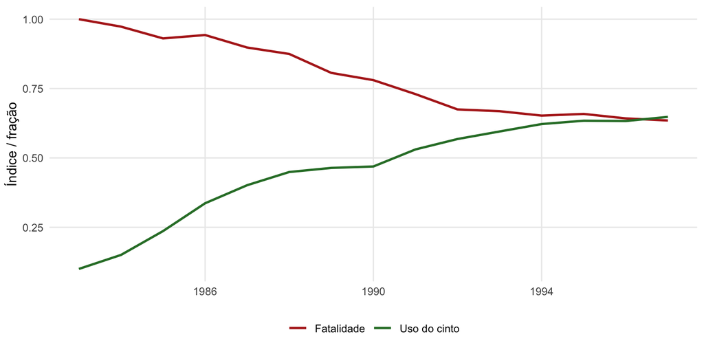

```r
media_ano <- sb |>
  group_by(year) |>
  summarise(fatalidade = mean(fatalityrate),
            uso = mean(sb_useage, na.rm = TRUE), .groups = "drop")

ggplot(media_ano, aes(year)) +
  geom_line(aes(y = fatalidade / max(fatalidade), color = "Fatalidade"), linewidth = 0.9) +
  geom_line(aes(y = uso, color = "Uso do cinto"), linewidth = 0.9) +
  scale_color_manual(values = c("Fatalidade" = vm, "Uso do cinto" = vd)) +
  labs(x = NULL, y = "Índice / fração")
```

A fatalidade cai ao longo de todo o período **e** o uso do cinto sobe. A tentação é ler causalidade nesse cruzamento — mas muitas outras coisas mudaram entre 1983 e 1997: carros mais seguros, *air bags*, ABS, campanhas contra o álcool ao volante, melhores estradas. É para isolar tudo isso que servem os **efeitos fixos de tempo**.

## 4 A progressão das especificações

Como no laboratório anterior, o argumento inteiro cabe numa sequência de regressões em que muda apenas **o que é mantido constante**.

**NotaNível ou log? A escolha da forma funcional**

A dependente entra em **nível** — mortes por milhão de milhas —, como na aula e no arquivo `SEATBELT.gdt`. A alternativa seria o **log**, e vale explicitar o que cada uma impõe, porque a escolha não é cosmética:

- **em nível**, o modelo assume que a lei retira o **mesmo número absoluto** de mortes de todo estado. Como o estado mais perigoso do painel tem cerca de $2{,}4$ vezes a taxa do mais seguro, isso implica quedas relativas muito diferentes entre eles — 13% num, 5% noutro;
- **em log**, assume-se efeito **proporcional** constante: a mesma queda percentual em toda parte, que é a hipótese mais natural para uma tecnologia de segurança.

O log tem ainda a vantagem de tornar a distribuição quase simétrica (a assimetria cai de $0{,}76$ para $-0{,}11$) e de produzir coeficientes lidos direto como porcentagem.

A razão de manter o **nível** como especificação principal é a comparabilidade com a saída do Gretl apresentada em aula — e, sobretudo, o fato de que **a escolha não muda as conclusões**: a seção de robustez mostra os dois lado a lado, com a mesma direção, a mesma significância marginal e magnitudes próximas ($-8\%$ em nível contra $-6\%$ em log). Quando duas formas funcionais concordam, reportar as duas vale mais que defender uma.

```r
# Especificacao principal: a fatalidade em NIVEL -- mortes por milhao de
# milhas --, como na aula e no arquivo SEATBELT.gdt. A variante em log
# aparece na secao de robustez.
f <- fatalityrate ~ primary + secondary + speed65 + speed70 + ba08 +
     drinkage21 + l_income + age

m1 <- lm(f, data = sb)                                              # MQO agrupado
m2 <- plm(f, data = psb, model = "within")                          # EF de estado
m3 <- plm(f, data = psb, model = "within", effect = "twoways")      # EF estado + tempo

# As duas colunas seguintes rodam na SUBAMOSTRA de 556 observacoes em que
# sb_useage existe. m4 repete a especificacao de m3 nessa subamostra -- e a
# comparacao honesta --, e m5 acrescenta o uso do cinto como regressor.
sb_uso  <- subset(sb, !is.na(sb_useage))
psb_uso <- pdata.frame(sb_uso, index = c("state", "year"))

m4 <- plm(f, data = psb_uso, model = "within", effect = "twoways")
m5 <- plm(update(f, . ~ . + sb_useage), data = psb_uso,
          model = "within", effect = "twoways")
```

```r
ep_cluster <- function(m) sqrt(diag(vcovHC(m, type = "HC1", cluster = "group")))

extrai <- function(m, nome, robusto_simples = FALSE) {
  e <- if (robusto_simples) sqrt(diag(vcovHC(m, type = "HC1"))) else ep_cluster(m)
  data.frame(
    especificacao = nome,
    primary   = coef(m)[["primary"]],   ep_primary   = e[["primary"]],
    secondary = coef(m)[["secondary"]], ep_secondary = e[["secondary"]]
  )
}

rbind(
  extrai(m1, "MQO agrupado", robusto_simples = TRUE),
  extrai(m2, "EF de estado"),
  extrai(m3, "EF estado + tempo")
) |>
  mutate(across(where(is.numeric), \(x) round(x, 4)),
         t_primary = round(primary / ep_primary, 2))
```

| especificacao | primary | ep_primary | secondary | ep_secondary | t_primary |
| --- | --- | --- | --- | --- | --- |
| MQO agrupado | 0.0011 | 5e-04 | 1e-04 | 4e-04 | 2.2 |
| EF de estado | -0.0017 | 1e-03 | -8e-04 | 5e-04 | -1.7 |
| EF estado + tempo | -0.0017 | 1e-03 | -5e-04 | 5e-04 | -1.7 |

**ImportanteA inversão de sinal, de novo**

Como a taxa média é $0{,}0215$, esse coeficiente equivale a uma queda de cerca de **8%** na fatalidade. A diferença em relação ao laboratório do *Guns* é o que acontece **depois** da inversão: lá o coeficiente colapsava para zero; aqui ele se estabiliza num valor **negativo e economicamente relevante**.

## 5 A tabela completa

```r
stargazer(m1, m2, m3, m4, m5,
  type = "html",
  se = list(sqrt(diag(vcovHC(m1, type = "HC1"))), ep_cluster(m2), ep_cluster(m3),
            ep_cluster(m4), ep_cluster(m5)),
  title = "Leis de cinto e fatalidade no trânsito",
  dep.var.labels = "Mortes por milhão de milhas",
  column.labels = c("Pooled", "EF estado", "EF 2 vias", "EF 2 vias", "EF 2 vias"),
  covariate.labels = c("Fiscalização primária", "Fiscalização secundária",
                       "Limite 65 mph", "Limite 70+ mph", "Alcoolemia 0,08",
                       "Idade 21 para beber", "log(renda)", "Idade média",
                       "Uso do cinto (fração)"),
  add.lines = list(
    c("Efeitos fixos de estado", "Não", "Sim", "Sim", "Sim", "Sim"),
    c("Efeitos fixos de tempo",  "Não", "Não", "Sim", "Sim", "Sim"),
    c("Amostra", "completa", "completa", "completa", "com uso", "com uso")
  ),
  omit.stat = c("f", "ser", "adj.rsq"),
  digits = 4,
  notes = paste("Erros-padrão clusterizados por estado (col. 1: robustos).",
                "Col. (4) e (5) usam as 556 observações em que o uso do cinto",
                "é observado; (4) é a comparação de amostra para (5)."),
  notes.align = "l"
)
```

**Leis de cinto e fatalidade no trânsito**

|  | *Dependent variable:* |  |  |  |  |
| --- | --- | --- | --- | --- | --- |
|  | Mortes por milhão de milhas |  |  |  | f |
|  | *OLS* | *panel* |  |  | *panel* |
|  |  | *linear* |  |  | *linear* |
|  | Pooled | EF estado | EF 2 vias | EF 2 vias | EF 2 vias |
|  | (1) | (2) | (3) | (4) | (5) |
| Fiscalização primária | 0.0011** | -0.0017* | -0.0017* | -0.0002 | 0.0005 |
|  | (0.0005) | (0.0010) | (0.0010) | (0.0009) | (0.0010) |
| Fiscalização secundária | 0.0001 | -0.0008* | -0.0005 | -0.0006* | -0.0003 |
|  | (0.0004) | (0.0005) | (0.0005) | (0.0004) | (0.0004) |
| Limite 65 mph | 0.0002 | -0.0011* | -0.0001 | -0.0008 | -0.0007 |
|  | (0.0004) | (0.0006) | (0.0009) | (0.0005) | (0.0005) |
| Limite 70+ mph | 0.0025*** | 0.0006 | 0.0003 | 0.0008* | 0.0008* |
|  | (0.0005) | (0.0005) | (0.0006) | (0.0005) | (0.0004) |
| Alcoolemia 0,08 | -0.0023*** | -0.0018*** | -0.0011* | -0.0009* | -0.0008* |
|  | (0.0004) | (0.0006) | (0.0006) | (0.0005) | (0.0004) |
| Idade 21 para beber | 0.0011 | 0.0012** | 0.0001 | -0.0013* | -0.0013* |
|  | (0.0007) | (0.0005) | (0.0006) | (0.0007) | (0.0007) |
| log(renda) | -0.0171*** | -0.0103*** | 0.0193*** | 0.0057 | 0.0059 |
|  | (0.0009) | (0.0016) | (0.0059) | (0.0067) | (0.0067) |
| Idade média | -0.0004** | -0.0009 | 0.0005 | 0.0013* | 0.0014** |
|  | (0.0002) | (0.0006) | (0.0007) | (0.0007) | (0.0007) |
| Uso do cinto (fração) |  |  |  |  | -0.0035** |
|  |  |  |  |  | (0.0017) |
| Constant | 0.2002*** |  |  |  |  |
|  | (0.0073) |  |  |  |  |
| Efeitos fixos de estado | Não | Sim | Sim | Sim | Sim |
| Efeitos fixos de tempo | Não | Não | Sim | Sim | Sim |
| Amostra | completa | completa | completa | com uso | com uso |
| Observations | 765 | 765 | 765 | 556 | 556 |
| R<sup>2</sup> | 0.5575 | 0.6810 | 0.0963 | 0.0713 | 0.0853 |
| *Note:* | *p<0.1; **p<0.05;*** p<0.01 |  |  |  |  |
|  | Erros-padrão clusterizados por estado (col. 1: robustos). Col. (4) e (5) usam as 556 observações em que o uso do cinto é observado; (4) é a comparação de amostra para (5). |  |  |  |  |

### 5.1 Lendo as colunas (4) e (5)

As duas últimas colunas respondem a uma pergunta que as três primeiras não alcançam: **o efeito da lei passa pelo uso do cinto?**

A comparação tem de ser feita com cuidado, porque elas rodam na subamostra de 556 observações. É para isso que existe a coluna (4): ela repete exatamente a especificação da coluna (3), mudando **apenas a amostra**. Comparar (3) com (5) misturaria dois efeitos — a mudança de amostra e a inclusão do regressor.

```r
data.frame(
  coluna = c("(3) EF 2 vias, amostra completa",
             "(4) EF 2 vias, subamostra com uso",
             "(5) idem + uso do cinto"),
  n = c(nobs(m3), nobs(m4), nobs(m5)),
  primary = round(c(coef(m3)[["primary"]], coef(m4)[["primary"]],
                    coef(m5)[["primary"]]), 4),
  sb_useage = c(NA, NA, round(coef(m5)[["sb_useage"]], 4))
)
```

| coluna | n | primary | sb_useage |
| --- | --- | --- | --- |
| (3) EF 2 vias, amostra completa | 765 | -0.0017 | NA |
| (4) EF 2 vias, subamostra com uso | 556 | -0.0002 | NA |
| (5) idem + uso do cinto | 556 | 0.0005 | -0.0035 |

Duas coisas acontecem, e é importante não confundi-las:

1. **De (3) para (4)**, o coeficiente de `primary` encolhe sem que nada tenha sido acrescentado à equação. A diferença é **inteiramente de amostra** — os estados-ano em que o uso do cinto é observado não são um recorte aleatório do painel.
2. **De (4) para (5)**, ao incluir o uso do cinto, o coeficiente da lei vai a praticamente **zero**, enquanto o uso do cinto entra com efeito negativo e significante a 10%.

**ImportanteIsto é o mecanismo aparecendo na tabela**

Daí uma consequência prática que vale reter: a coluna (5) **não** é a especificação preferida para medir o efeito da lei. Controlar pelo mediador responde a outra pergunta — “qual o efeito da lei que *não* passa pelo cinto?” —, e a resposta, aqui, é: praticamente nenhum. Para o efeito total da política, a especificação correta é a coluna (3).

## 6 O teste da dose-resposta

Aqui está o argumento que distingue este caso de uma correlação qualquer. Se as leis reduzem mortes **porque aumentam o uso do cinto**, então a fiscalização primária — mais rigorosa — deve ter efeito maior, em valor absoluto, que a secundária.

```r
coefs <- coef(m3)
eps   <- ep_cluster(m3)
media_fat <- mean(sb$fatalityrate)

# em nivel o coeficiente ja e a variacao absoluta da taxa; a coluna
# "% da media" o traduz para a escala relativa, comparavel entre regimes
data.frame(
  regime     = c("Fiscalização primária", "Fiscalização secundária"),
  efeito     = round(coefs[c("primary", "secondary")], 6),
  pct_media  = round(100 * coefs[c("primary", "secondary")] / media_fat, 2),
  ep         = round(eps[c("primary", "secondary")], 6),
  t          = round(coefs[c("primary", "secondary")] / eps[c("primary", "secondary")], 2),
  row.names  = NULL
)
```

| regime | efeito | pct_media | ep | t |
| --- | --- | --- | --- | --- |
| Fiscalização primária | -0.001730 | -8.05 | 0.001010 | -1.71 |
| Fiscalização secundária | -0.000508 | -2.37 | 0.000503 | -1.01 |

A ordenação prevista pela teoria **aparece nos dados**: o efeito da fiscalização primária é cerca de três vezes o da secundária. Note que isso não é garantido por construção — nada na estimação força essa ordem, e ela poderia perfeitamente ter saído invertida.

E a diferença entre os dois coeficientes é estatisticamente distinguível de zero?

```r
# H0: beta_primary = beta_secondary, via estatistica de Wald
V <- vcovHC(m3, type = "HC1", cluster = "group")
R <- matrix(0, nrow = 1, ncol = length(coef(m3)))
colnames(R) <- names(coef(m3))
R[1, "primary"]   <-  1
R[1, "secondary"] <- -1

dif  <- as.numeric(R %*% coef(m3))
sedif <- sqrt(as.numeric(R %*% V %*% t(R)))

c(diferenca = round(dif, 4), ep = round(sedif, 4),
  t = round(dif / sedif, 2), p = round(2 * pnorm(-abs(dif / sedif)), 3))
```

```
diferenca        ep         t         p
  -0.0012    0.0011   -1.1500    0.2490
```

A diferença tem o sinal certo, mas o teste **não rejeita** a igualdade a 5%. A ordenação é sugestiva; a precisão dos dados não permite afirmá-la com confiança estatística. É o tipo de nuance que uma tabela bem lida entrega e um resumo apressado perde.

## 7 O canal causal: as leis aumentam o uso do cinto?

Todo o argumento repousa num mecanismo postulado: a lei aumenta o uso do cinto, e o cinto salva vidas. O primeiro elo é **diretamente verificável** nestes dados.

```r
m_uso <- plm(sb_useage ~ primary + secondary + speed65 + speed70 + ba08 +
               drinkage21 + l_income + age,
             data = psb_uso, model = "within", effect = "twoways")

e_uso <- ep_cluster(m_uso)
data.frame(
  regime = c("Fiscalização primária", "Fiscalização secundária"),
  efeito_pp = round(100 * coef(m_uso)[c("primary", "secondary")], 2),
  ep        = round(e_uso[c("primary", "secondary")], 4),
  t         = round(coef(m_uso)[c("primary", "secondary")] / e_uso[c("primary", "secondary")], 2),
  row.names = NULL
)
```

| regime | efeito_pp | ep | t |
| --- | --- | --- | --- |
| Fiscalização primária | 20.56 | 0.0227 | 9.08 |
| Fiscalização secundária | 10.85 | 0.0131 | 8.28 |

O primeiro elo da cadeia é **forte e inequívoco**. Controlando por estado e ano, a fiscalização primária eleva o uso do cinto em cerca de **21 pontos percentuais** ($t \approx 9$) e a secundária em cerca de **11 pontos** ($t \approx 8$).

Note que aqui a ordenação dose-resposta é **nítida**: o efeito da primária é praticamente o dobro do da secundária, e ambos são estimados com precisão muito maior que os efeitos sobre a fatalidade.

**ImportantePor que o primeiro elo é mais preciso que o segundo**

O contraste entre esta tabela e a da seção anterior é instrutivo. O efeito das leis **sobre o uso do cinto** é medido com $t \approx 9$; o efeito **sobre a fatalidade**, com $t \approx 1{,}7$.

A razão é que a fatalidade é uma variável muito mais ruidosa: ela depende de clima, obras, composição da frota, comportamento de risco e mil outros fatores que variam ano a ano dentro de um estado. O sinal da lei está lá, mas afogado em variância. O uso do cinto, ao contrário, responde à lei de forma quase mecânica.

Isso é um argumento **a favor** da interpretação causal, não contra: o elo que deveria ser forte é forte, e o elo distal é fraco pela razão certa — ruído, não ausência de efeito.

## 8 O segundo elo: o uso do cinto reduz mortes?

A Seção 7 estabeleceu o primeiro elo da cadeia — as leis aumentam o uso do cinto. Falta o segundo: **o uso do cinto reduz as mortes?** Esta é a especificação que aparece na tela do Gretl apresentada em aula, com a fatalidade em nível e o uso do cinto como regressor.

```r
sb_uso2 <- subset(sb, !is.na(sb_useage))
psb_uso2 <- pdata.frame(sb_uso2, index = c("state", "year"))

m_elo2 <- plm(fatalityrate ~ sb_useage + drinkage21 + l_income + speed65 + speed70 +
                factor(year), data = psb_uso2, model = "within")

ct2 <- coeftest(m_elo2, vcov = vcovHC(m_elo2, type = "HC1", cluster = "group"))
round(ct2[c("sb_useage", "drinkage21", "l_income", "speed65", "speed70"), ], 8)
```

```
              Estimate Std. Error    t value   Pr(>|t|)
sb_useage  -0.00335185 0.00142862 -2.3462117 0.01936617
drinkage21 -0.00067803 0.00065422 -1.0363884 0.30053636
l_income    0.00826876 0.00671131  1.2320632 0.21852124
speed65    -0.00072216 0.00065574 -1.1012901 0.27131556
speed70     0.00040905 0.00049679  0.8233763 0.41069786
```

O coeficiente de `sb_useage` é $-0{,}00335$, com $t = -2{,}35$: negativo e significante a 5%.

### 8.1 Como interpretar esse número

A interpretação exige atenção às **unidades das duas variáveis**, e é um caso em que o coeficiente bruto engana:

- a dependente é a taxa de fatalidade em **mortes por milhão de milhas**;
- o regressor é o uso do cinto como **fração** (0 a 1), não em porcentagem.

Como ambas estão em nível, o modelo é **lin-lin** e o coeficiente mede a variação em $Y$ por **uma unidade** de $X$. Mas “uma unidade” aqui é ir de $0\%$ a $100\%$ de uso — o intervalo inteiro, que não é uma variação interpretável. A leitura útil exige reescalar para **1 ponto percentual**, isto é, multiplicar por $0{,}01$:

```r
b_uso <- coef(m_elo2)[["sb_useage"]]
media_fat <- mean(sb_uso2$fatalityrate)

c(coeficiente_bruto   = round(b_uso, 8),
  efeito_1_pp         = b_uso * 0.01,
  media_fatalidade    = round(media_fat, 6),
  efeito_1_pp_em_pct  = round(100 * b_uso * 0.01 / media_fat, 3),
  efeito_10_pp_em_pct = round(100 * b_uso * 0.10 / media_fat, 2))
```

```
  coeficiente_bruto         efeito_1_pp    media_fatalidade  efeito_1_pp_em_pct
      -3.351850e-03       -3.351851e-05        1.976900e-02       -1.700000e-01
efeito_10_pp_em_pct
      -1.700000e+00
```

Um aumento de **1 ponto percentual** no uso do cinto reduz a taxa de fatalidade em $0{,}0000335$ mortes por milhão de milhas — mantidos constantes o estado, o ano e os demais controles. Em termos relativos, isso é cerca de **0,17% da média** amostral. Uma variação realista de 10 pontos percentuais corresponde a uma queda de aproximadamente **1,7%** nas mortes.

**AvisoTrês ressalvas sobre este coeficiente**

**(i) A amostra é outra.** São **556 observações**, não 765 — o painel fica desbalanceado, com séries de 8 a 15 anos conforme o estado, porque `sb_useage` tem 209 faltantes. Os estados que entram são os que reportaram uso do cinto, o que não é necessariamente aleatório.

**(ii) Este coeficiente não é causal no mesmo sentido que o das leis.** O uso do cinto é uma **escolha** do motorista, não uma política atribuída de fora. Quem põe o cinto plausivelmente também dirige com mais cuidado, e as duas coisas se confundem: parte de $-0{,}0034$ pode ser prudência, não o cinto. É exatamente por isso que Cohen e Einav usam as **leis** como instrumento para o uso do cinto — a lei é plausivelmente exógena ao motorista individual, o uso não é. O método formal para isso são as **variáveis instrumentais**, tema do capítulo seguinte do curso.

**(iii) Há compensação de risco.** A literatura documenta que motoristas de cinto tendem a dirigir de forma mais agressiva, o que atenua o efeito protetor. Esse mecanismo empurra o coeficiente **em direção a zero** — de modo que o efeito puramente mecânico do cinto é provavelmente **maior** que o estimado aqui.

### 8.2 A cadeia completa

Juntando os dois elos, temos o argumento causal na forma em que ele deve ser avaliado:

```r
# forma reduzida na escala de niveis, para comparar com o produto dos elos
reduzida <- plm(fatalityrate ~ primary + secondary + speed65 + speed70 + ba08 +
                  drinkage21 + l_income + age, data = psb,
                model = "within", effect = "twoways")

elo1 <- coef(m_uso)[["primary"]]          # lei -> uso (pontos de fracao)
elo2 <- coef(m_elo2)[["sb_useage"]]       # uso -> fatalidade

data.frame(
  elo = c("Lei primária → uso do cinto",
          "Uso do cinto → fatalidade",
          "Efeito indireto implícito (produto)",
          "Efeito direto estimado (reduzido)"),
  valor = c(round(elo1, 4),
            round(elo2, 5),
            round(elo1 * elo2, 6),
            round(coef(reduzida)[["primary"]], 6)),
  unidade = c("+pp de uso", "mortes/milhão de milhas por unidade de uso",
              "mortes/milhão de milhas", "mortes/milhão de milhas")
)
```

| elo | valor | unidade |
| --- | --- | --- |
| Lei primária → uso do cinto | 0.205600 | +pp de uso |
| Uso do cinto → fatalidade | -0.003350 | mortes/milhão de milhas por unidade de uso |
| Efeito indireto implícito (produto) | -0.000689 | mortes/milhão de milhas |
| Efeito direto estimado (reduzido) | -0.001730 | mortes/milhão de milhas |

O **efeito indireto implícito** — o produto dos dois elos — é a queda na fatalidade que se esperaria *se todo o efeito da lei passasse pelo uso do cinto*. Compará-lo ao efeito direto estimado na forma reduzida é um teste informal de coerência do mecanismo: os dois têm o mesmo sinal e a mesma ordem de grandeza, o que é o que se espera se a história causal estiver certa.

## 9 Replicando a saída do Gretl

A especificação principal deste laboratório é deliberadamente a da aula — a fatalidade em **nível**, com `l_income` como controle. O arquivo `SEATBELT.gdt` usa *dummies* de tempo explícitas (`dt_1`…`dt_15`) em vez do argumento `effect = "twoways"`; as duas formas são equivalentes, como as notas da disciplina registram, e a estimação abaixo confirma.

```r
m_gretl <- plm(fatalityrate ~ primary + secondary + speed65 + speed70 + ba08 +
                 drinkage21 + l_income + age + factor(year),
               data = psb, model = "within")

ct <- coeftest(m_gretl, vcov = vcovHC(m_gretl, type = "HC1", cluster = "group"))
round(ct[c("primary", "secondary", "ba08", "l_income", "age"), ], 7)
```

```
            Estimate Std. Error    t value  Pr(>|t|)
primary   -0.0017299  0.0010193 -1.6972133 0.0901060
secondary -0.0005084  0.0005081 -1.0006637 0.3173392
ba08      -0.0010722  0.0006307 -1.6999064 0.0895979
l_income   0.0193461  0.0059399  3.2569728 0.0011810
age        0.0004869  0.0007173  0.6787847 0.4975012
```

A fiscalização primária reduz a taxa em $0{,}00173$ morte por milhão de milhas. Como a média amostral é cerca de $0{,}0215$, isso equivale a uma queda de aproximadamente **8%** — e o número coincide com o da coluna (3) da tabela principal, como tinha de ser.

```r
c(media_fatalidade = round(mean(sb$fatalityrate), 5),
  efeito_primary   = round(coef(m_gretl)[["primary"]], 6),
  efeito_relativo_pct = round(100 * coef(m_gretl)[["primary"]] / mean(sb$fatalityrate), 2))
```

```
   media_fatalidade      efeito_primary efeito_relativo_pct
            0.02149            -0.00173            -8.05000
```

## 10 Quantas vidas? A tradução para números absolutos

Um coeficiente em log não conversa com política pública. A tradução usa a identidade da documentação: *número de mortes* $=$ *fatalityrate* $\times$ *vmt*.

```r
# Contrafactual: os estados que em 1997 ainda nao tinham fiscalizacao
# primaria passam a te-la. As duas formas funcionais dao contas diferentes,
# e a diferenca entre elas e exatamente a hipotese que cada uma impoe.
ultimo  <- subset(sb, year == max(sb$year))
sem_lei <- subset(ultimo, primary == 0)

mortes_hoje    <- with(ultimo,  sum(fatalityrate * vmt))
mortes_sem_lei <- with(sem_lei, sum(fatalityrate * vmt))

# (a) em NIVEL: efeito absoluto por milhao de milhas x milhas desses estados
vidas_nivel <- -coef(m3)[["primary"]] * sum(sem_lei$vmt)

# (b) em LOG: efeito proporcional x mortes observadas desses estados
m3_log <- plm(lfat ~ primary + secondary + speed65 + speed70 + ba08 +
                drinkage21 + l_income + age, data = psb,
              model = "within", effect = "twoways")
vidas_log <- -(exp(coef(m3_log)[["primary"]]) - 1) * mortes_sem_lei

data.frame(
  base = c("Nível (esp. principal)", "Log (robustez)"),
  vidas_salvas = round(c(vidas_nivel, vidas_log)),
  pct_das_mortes_do_grupo = round(100 * c(vidas_nivel, vidas_log) / mortes_sem_lei, 1),
  pct_do_total_nacional   = round(100 * c(vidas_nivel, vidas_log) / mortes_hoje, 1)
)
```

| base | vidas_salvas | pct_das_mortes_do_grupo | pct_do_total_nacional |
| --- | --- | --- | --- |
| Nível (esp. principal) | 3530 | 10.6 | 8.4 |
| Log (robustez) | 2017 | 6.0 | 4.8 |

Se os 43 estados que ainda não tinham fiscalização primária em 1997 a tivessem adotado, a conta fica entre **2.000 e 3.500 mortes a menos por ano** — algo entre 5% e 8% do total nacional.

A distância entre os dois números não é erro de cálculo: é a **hipótese de cada forma funcional** aparecendo no resultado. Esses 43 estados têm taxa de fatalidade **abaixo** da média do painel, e por isso:

- o modelo **em nível**, que lhes atribui a mesma redução absoluta de todos, implica uma queda relativa maior neles ($10{,}6\%$) — e mais vidas salvas;
- o modelo **em log**, que impõe queda proporcional constante, aplica os mesmos $6\%$ e chega a um número menor.

Reportar a faixa é mais honesto que escolher um dos extremos. A estimativa é imprecisa também pelas razões estatísticas já discutidas — o intervalo de confiança do próprio coeficiente é largo —, mas a ordem de grandeza é a que a discussão de política pública exige: **milhares** de vidas por ano, não dezenas nem centenas de milhares.

**AvisoUm contrafactual, não uma previsão**

O cálculo extrapola o coeficiente médio estimado para estados que **escolheram não adotar** a lei. Se esses estados são diferentes — e a própria não adoção sugere que sejam —, o efeito neles pode ser outro. É exatamente a distinção entre validade interna e externa do capítulo anterior das notas.

## 11 Testes de especificação

```r
pFtest(m2, plm(f, data = psb, model = "pooling"))
```

```
    F test for individual effects

data:  f
F = 29.343, df1 = 50, df2 = 706, p-value < 2.2e-16
alternative hypothesis: significant effects
```

```r
phtest(m2, plm(f, data = psb, model = "random"))
```

```
    Hausman Test

data:  f
chisq = 11.662, df = 8, p-value = 0.167
alternative hypothesis: one model is inconsistent
```

## 12 Robustez

```r
# (a) dependente em LOG, em vez de nivel -- a forma funcional alternativa
rb1 <- plm(lfat ~ primary + secondary + speed65 + speed70 + ba08 +
             drinkage21 + l_income + age, data = psb,
           model = "within", effect = "twoways")

# (b) tratamento unico: qualquer lei de cinto
sb$qualquer_lei <- as.integer(sb$primary == 1 | sb$secondary == 1)
psb2 <- pdata.frame(sb, index = c("state", "year"))
rb2 <- plm(fatalityrate ~ qualquer_lei + speed65 + speed70 + ba08 + drinkage21 +
             l_income + age, data = psb2, model = "within", effect = "twoways")

# (c) sem controles, so as leis
rb3 <- plm(fatalityrate ~ primary + secondary, data = psb,
           model = "within", effect = "twoways")

data.frame(
  especificacao = c("Base (nível, controles)", "Dependente em log",
                    "Qualquer lei de cinto", "Sem controles"),
  coef = round(c(coef(m3)[["primary"]], coef(rb1)[["primary"]],
                 coef(rb2)[["qualquer_lei"]], coef(rb3)[["primary"]]), 5),
  t = round(c(coef(m3)[["primary"]] / ep_cluster(m3)[["primary"]],
              coef(rb1)[["primary"]] / ep_cluster(rb1)[["primary"]],
              coef(rb2)[["qualquer_lei"]] / ep_cluster(rb2)[["qualquer_lei"]],
              coef(rb3)[["primary"]] / ep_cluster(rb3)[["primary"]]), 2)
)
```

| especificacao | coef | t |
| --- | --- | --- |
| Base (nível, controles) | -0.00173 | -1.71 |
| Dependente em log | -0.06226 | -1.68 |
| Qualquer lei de cinto | -0.00066 | -1.39 |
| Sem controles | -0.00140 | -1.27 |

O sinal negativo se mantém em todas as variantes. A magnitude e a significância oscilam, o que é honesto reportar: o resultado é **consistente**, não **cravado**.

## 13 Conclusão

**Sobre o método.** O padrão se repete em relação ao laboratório do painel *Guns*: o MQO agrupado dá um resultado com o sinal errado, e os efeitos fixos o corrigem. A diferença está no destino — no caso das armas, o efeito ia a zero; aqui, ele se estabiliza num valor negativo de cerca de $-8\%$ da fatalidade média, com $t \approx 1{,}7$ — e a conclusão não depende de a dependente entrar em nível ou em log.

**Sobre o caso.** A evidência é *consistente* com leis de cinto salvando vidas, e mais forte que a mera correlação porque três coisas apontam na mesma direção:

Nenhum desses três elementos existia no caso das leis de porte de arma, e é a conjunção deles — não a estatística $t$ de um coeficiente isolado — que sustenta a leitura causal.

**Sobre o que fica em aberto.** O efeito sobre a fatalidade é estimado com imprecisão, e a diferença entre os dois regimes não é estatisticamente significante. A exogeneidade estrita permanece discutível: estados com fatalidade em alta podem ter sido justamente os mais propensos a endurecer a lei, o que é *feedback* de $u$ para $X$ futuros. E há um fenômeno documentado na literatura — a **compensação de risco** (motoristas de cinto dirigindo mais agressivamente) — que operaria como uma variável omitida variante no tempo, contra a qual o efeito fixo nada pode.

## 14 Referências

- Cohen, A. e Einav, L. (2003). “The Effects of Mandatory Seat Belt Laws on Driving Behavior and Traffic Fatalities”. *The Review of Economics and Statistics*, 85(4), 828–843.
- Stock, J. H. e Watson, M. W. (2020). *Introduction to Econometrics*, 4ª ed., cap. 10.